# Generative network models

Exercises.

Authors

Affiliations

Ben Kawam

Max Planck Institute of Animal Behavior

Daniel Redhead

University of Groningen

Published

June 29, 2026

Abstract

This notebook contains exercises for participants of the EFP 2026 workshop on animal social network analsis.

```r
# install the tidyverse package if not already on your laptop
if (!requireNamespace("tidyverse", quietly = TRUE)) {
  install.packages("tidyverse")
}

# load the package
library(tidyverse)
```

# Exercise 1

The code chunk below produces 10 binary outcomes with a fixed probability $p$. These outcomes can represent behaviours; *e.g.*, whether individuals are foraging ($Y = 1$) or not ($Y = 0$) during one scan sample.

Listing 1: Generative model A

```r
(Y <- rbinom(
    n = 10,    # Number of units
    size = 1,  # Number of trials per i
    prob = 0.4 # p
))
```

```
 [1] 1 0 1 0 0 1 1 0 0 0
```

This generative model can be represented qualitatively using a Directed Acyclic Graph (DAG)—see Figure 1.

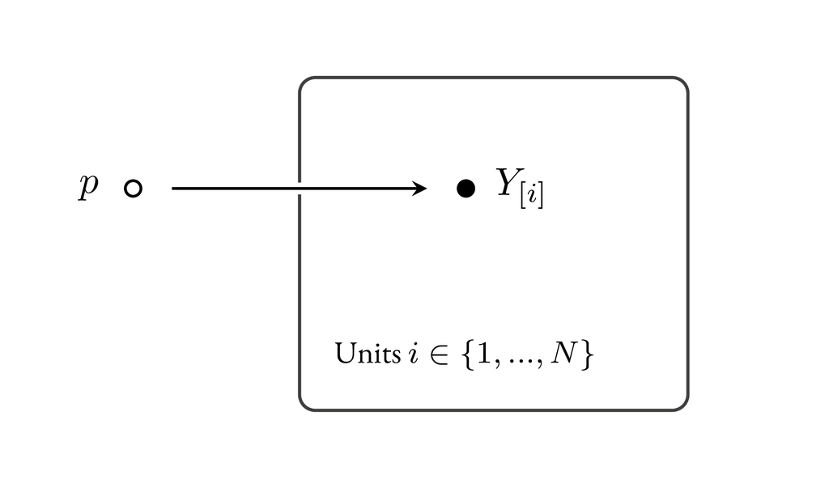

Figure 1: *Plated DAG of the Bernoulli data-generating process.* Nodes represent random variables, and arrows causal effects (not individuals and social ties!). The plate—rectangle with rounded edges—represents a loop over units $i$.

Run Generative model A a few times and observe what you obtain.

**Exercise 1.1.** (i) Change the probability of foraging such that this behaviour becomes rarer; (ii) increase the number of individuals to 120; (iii) increase the number of scans per individual to 12.

# Exercise 2

Consider the generative model below—a modified version of the Erdős–Rényi model.

Listing 2: Generative model B

```r
# specify number of individuals
N <- 10

# Number of dyads
N_dyad <- N * (N - 1) / 2

df_2 <- tibble(
  dyad = 1:N_dyad, # dyad number
  p = 0.4,         # fixed prob.
  S = 4,           # fixed number of scans

  # how many times were i and j observed interacting
  Y_ij = rbinom(N_dyad, S, p)
)

# print resulting data frame
df_2
```

```
# A tibble: 45 × 4
    dyad     p     S  Y_ij
   <int> <dbl> <dbl> <int>
 1     1   0.4     4     1
 2     2   0.4     4     1
 3     3   0.4     4     1
 4     4   0.4     4     0
 5     5   0.4     4     1
 6     6   0.4     4     1
 7     7   0.4     4     2
 8     8   0.4     4     1
 9     9   0.4     4     3
10    10   0.4     4     3
# ℹ 35 more rows
```

This model can be represented as a DAG (Figure 2):

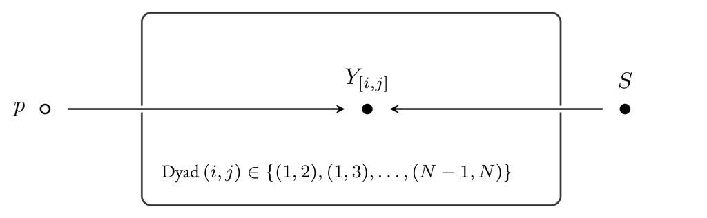

Figure 2: *Random binomial network model (not an official name).* A fixed probability $p$, together with a fixed number of trials $S$ jointly affect Binomial outcomes $Y_{[i,j]}$.

**Exercise 2.1.** Run Generative model B a couple of times and try to understand what each line does. What has changed compared to Generative model A?

**Exercise 2.2.** Instead of a fixed probability across dyads $(i, j)$, modify Generative model B so that different dyads have different probabilities of interacting. Specifically, draw the probabilities from a Beta distribution with parameters $\alpha = 2$ and $\beta = 2$. The `rbeta()` R function can help you do that.

**Exercise 2.3.** Similarly, change the code such that different dyads are observed for different amounts of time: draw sampling efforts $S_{[i,j]}$ from a Poisson distribution with rate $\lambda = 5$ periods per dyad on average, using the `rpois()` R function.

**Exercise 2.4.** Does the DAG change following the modifications brought by **Exercises 2.2.** and **2.3**? If so, how? If not, why not?

# Exercise 3

In this exercise, we will study the stochastic block model introduced during the workshop. Figure 3 shows the DAG corresponding to the corresponding data-generating process.

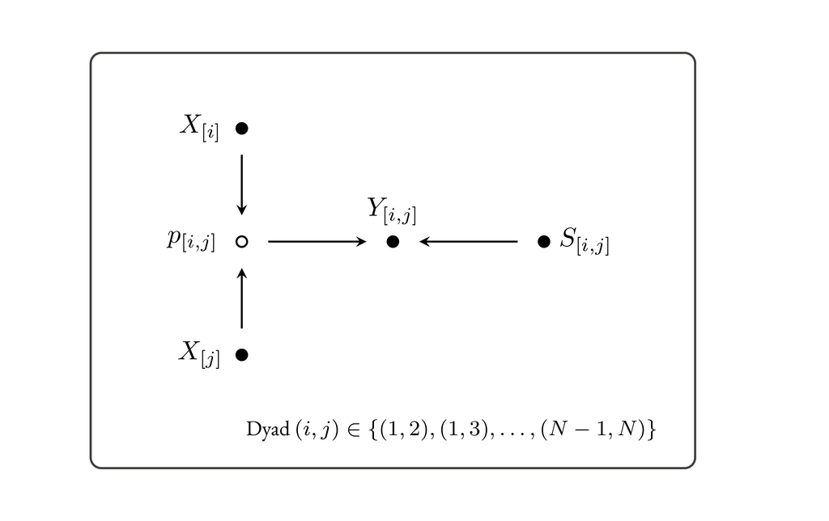

Figure 3: *Causal process underlying the stochastic block model.* The probability of interaction, $p_{[i,j]}$, if affected by the sex of individual $i$, $X_{[i]}$ and the sex of individual $j$, $X_{[j]}$. The rest of the model is identical to Figure 2.

We start by defining the number of total scans that we perform, as well as the block matrix $\theta$.

Listing 3: Generative model C (1/4)

```r
N_total_scans <- 20

# block matrix with p. interaction for
# each sex combination
theta <- matrix(c(0.3, 0.15,
                  0.15, 0.1),
                nrow = 2, ncol = 2)
```

We then construct a data frame for individual- and dyad-level features.

Listing 4: Generative model C (2/4)

```r
# data frame with individual features
df_ind <- tibble(
  ind = 1:N,
  X   = rep(c(1, 2), each = N / 2)
)

# data frame for dyads
df_dyad <- crossing(
    ind_i = 1:N,
    ind_j = 1:N
  ) %>%
    filter(ind_i < ind_j) %>%
    mutate(dyad = 1:n())
```

Next, we have scan sampling. We write a `for` loop across scans: there is a fixed probability to observe an individual during any one scan.

Listing 5: Generative model C (3/4)

```r
# empty lists
df_ind_scan <- list()
df_dyad_scan <- list()

# for each scan
for(scan in 1:N_total_scans){

  # we observe each ind. with a fixed probability
  df_ind_scan[[scan]] <- df_ind %>%
    mutate(
      observed = rbinom(N, 1, 0.4))

  # reorganise this information for dyads; "observed" becomes
  # observed_i and observed_j
  df_dyad_scan[[scan]] <- df_dyad %>%
      left_join(df_ind_scan[[scan]], by = c("ind_i" = "ind")) %>%
        rename(observed_i = observed, X_i = X) %>%
        left_join(df_ind_scan[[scan]], by = c("ind_j" = "ind")) %>%
        rename(observed_j = observed, X_j = X) %>%
        mutate(scan_no = scan)
} # end for
```

Finally, we compute $S_{[i,j]}$—encoding the number of times that each dyad could have been observed interacting, or the number of “binomial trials”—, retrieve $p_{[i,j]}$ for each dyad from the matrix $\theta$, and draw the number of grooming events $Y_{[i,j]}$ for each dyad.

Listing 6: Generative model C (4/4)

```r
# S_ij is the number of times i OR j were observed
df_3 <- df_dyad_scan %>%
  bind_rows() %>%
  group_by(ind_i, ind_j, dyad, X_i, X_j) %>%
  summarise(S_ij = sum(observed_i == 1 | observed_j == 1),
            .groups = "drop") %>%
  ungroup()

# We draw the number of grooming interactions Y_ij
(df_3 <- df_3 %>%
  mutate(p_ij = theta[cbind(X_i, X_j)],
         Y_ij = rbinom(N_dyad, S_ij, p_ij)))
```

```
# A tibble: 45 × 8
   ind_i ind_j  dyad   X_i   X_j  S_ij  p_ij  Y_ij
   <int> <int> <int> <dbl> <dbl> <int> <dbl> <int>
 1     1     2     1     1     1    14  0.3      3
 2     1     3     2     1     1    14  0.3      6
 3     1     4     3     1     1    13  0.3      5
 4     1     5     4     1     1    11  0.3      2
 5     1     6     5     1     2    12  0.15     3
 6     1     7     6     1     2    14  0.15     2
 7     1     8     7     1     2    14  0.15     3
 8     1     9     8     1     2    13  0.15     2
 9     1    10     9     1     2    17  0.15     4
10     2     3    10     1     1    14  0.3      4
# ℹ 35 more rows
```

Try to run and understand the code chunks above; *i.e.*, Generative model C (1/4)-Generative model C (4/4).

**Exercise 3.1.** What information is encoded in `df_dyad_scan[[7]]`?

**Exercise 3.2.** Why, in Generative model C (4/4), did we write `S_ij = sum(observed_i == 1 | observed_j == 1)`? In other words, why did we need to see *either* $i$ *or* $j$ in a scan—instead of, for example, *both* $i$ *and* $j$—to be counted as part of the sampling effort $S_{[i,j]}$?

**Exercise 3.3.** Suppose that individual sex were to affect sampling effort. How would you modify Figure 3 accordingly?

**Exercise 3.4.** How could you translate the causal effect of individual sex on $S_{[i,j]}$ into code? Writing your response in English—for example, with reference to the relevant code chunks—is sufficient.